# Predicción Conformal — Sulam

## Regresión cuantílica (CQR)

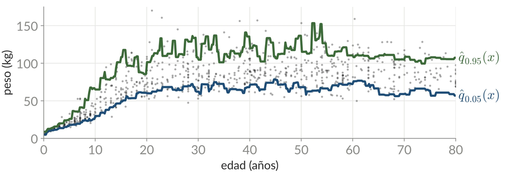

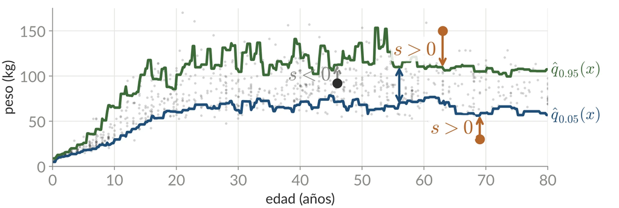

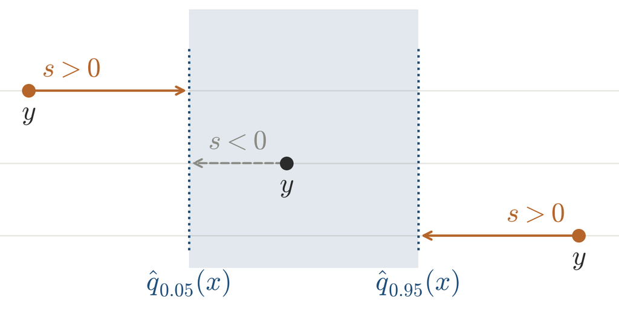

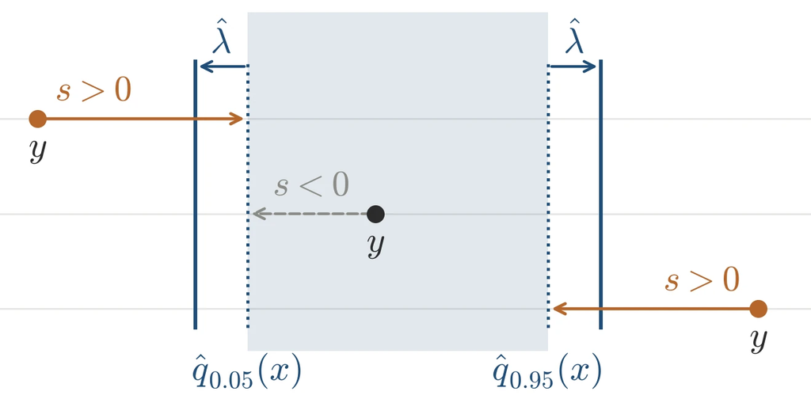

Score: distancia con signo al intervalo
$$s(x,y) = \max\big\{\hat q_{0.05}(x) - y,\ y-\hat q_{0.95}(x)\big\}$$

$$\Ch(x)=\big[\hat q_{0.05}(x)-\qh,\ \hat q_{0.95}(x)+\qh\big]$$

[Romano, Patterson & Candès, 2019]

## Regresión cuantílica

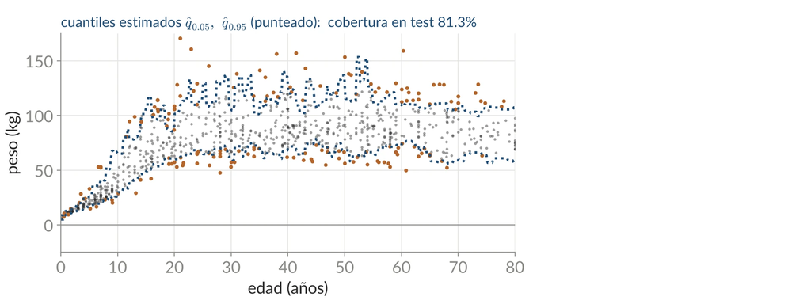

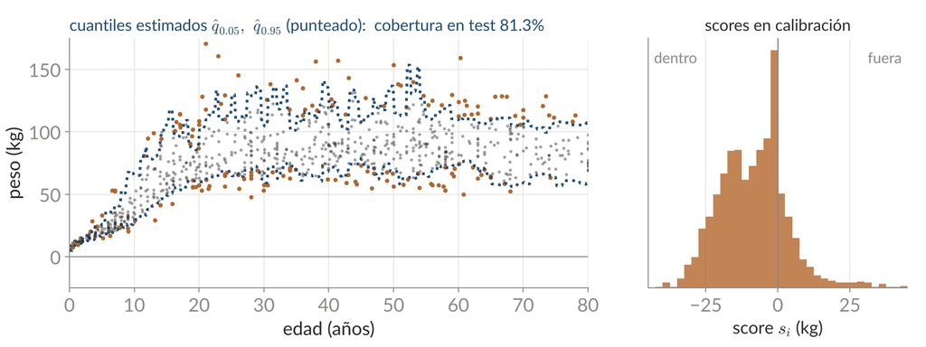

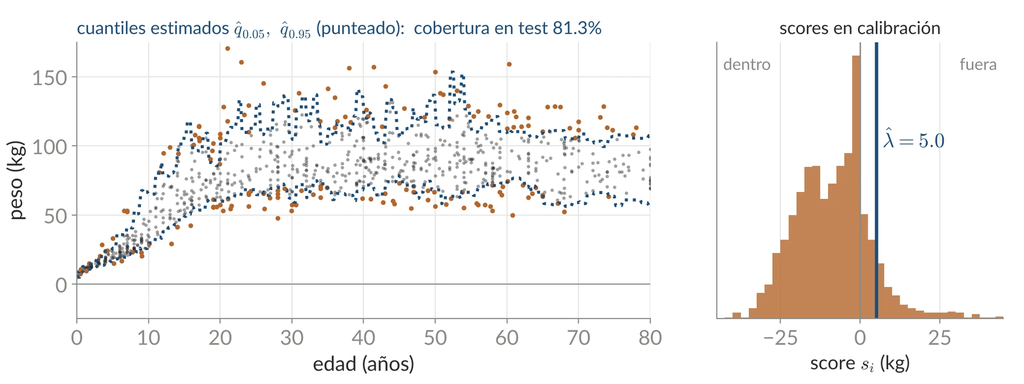

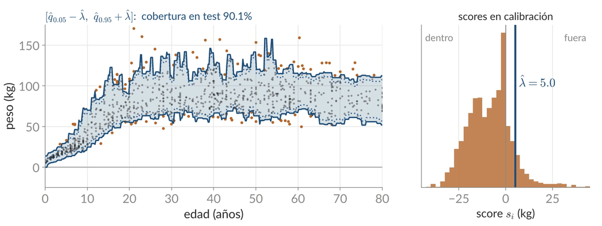

Cuantiles estimados: 81.3%. Conformalizados ($\qh=5.0$ kg): 90.1%.

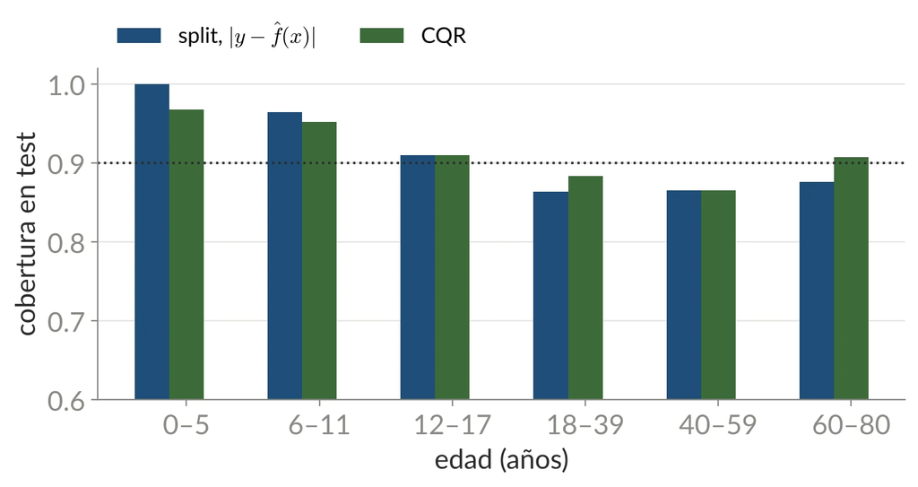

Q2: ¿Cómo se generaliza y dónde se aplica?

CQR

clasificación

cobertura condicional

control de riesgo

en línea

## Clasificación conformal

Ahora $Y\in\{1,\dots,K\}$ es una **etiqueta** (ImageNet: $K=1000$ clases).

El modelo da probabilidades $\fh_1(x),\dots,\fh_K(x)$ (softmax) y la predicción usual es $\ \arg\max_y \fh_y(x)$.

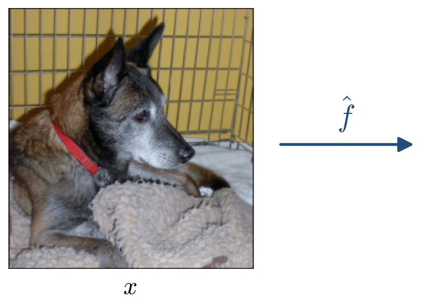

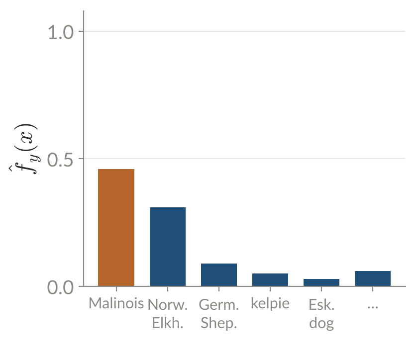

Conformal da un **conjunto** de etiquetas $\ \Ch(x)\subseteq\{1,\dots,K\}\$ con
$$\P\big(Y\in\Ch(X)\big)\ \ge\ 1-\alpha$$

## Clasificación conformal

1. Scores en calibración

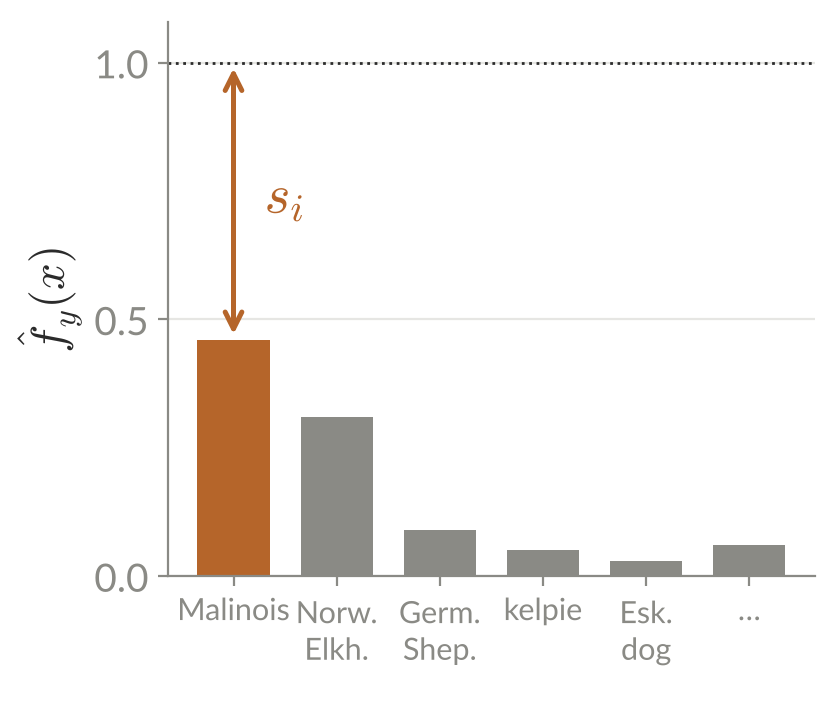

$s_i=1-\fh_{Y_i}(X_i)$

→

2. Cuantil de los scores

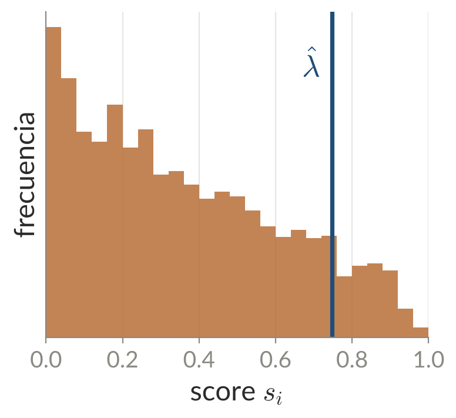

$\qh$ = cuantil de nivel $\tfrac{\lceil (n+1)(1-\alpha)\rceil}{n}$

→

3. Conjuntos en test

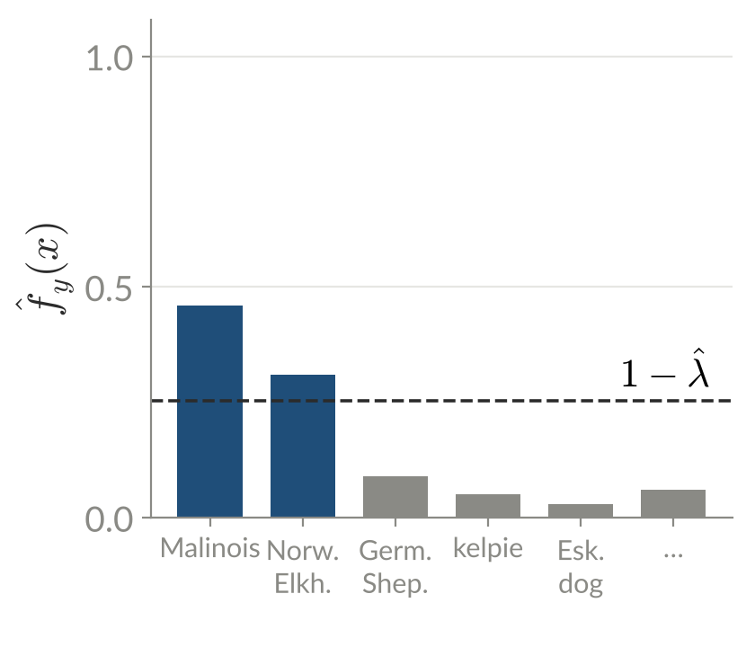

$\Ch(x)=\big\{y:\ \fh_y(x)\ge 1-\qh\big\}$

Lo único que cambia es el score.

Teorema. [Vovk et al, 2005; Lei et al, 2018] Si $(X_1,Y_1),\dots,(X_{n+1},Y_{n+1})$ son intercambiables, entonces $\ \P\big(Y_{n+1}\in\Ch(X_{n+1})\big)\ge 1-\alpha$.

## Clasificación conformal

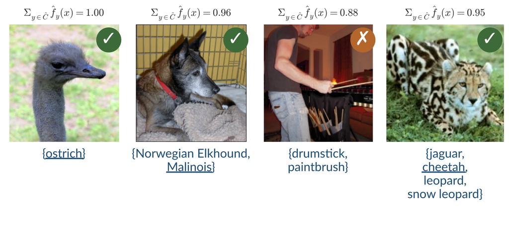

Teorema. [Vovk et al, 2005; Lei et al, 2018] Si $(X_1,Y_1),\dots,(X_{n+1},Y_{n+1})$ son intercambiables, entonces $\ \P\big(Y_{n+1}\in\Ch(X_{n+1})\big)\ge 1-\alpha$.

[Sadinle, Lei & Wasserman, 2019][Angelopoulos & Bates, 2023]

Q2: ¿Cómo se generaliza y dónde se aplica?

CQR

clasificación

cobertura condicional

control de riesgo

en línea

## Cobertura condicional

Conformal garantiza cobertura **marginal**, no **condicional**:

$$\P\big(Y\in\Ch(X)\big)\ge 1-\alpha \qquad\not\Rightarrow\qquad \P\big(Y\in\Ch(X)\mid X=x\big)\ge 1-\alpha$$

Sin más supuestos, cobertura condicional en $X$ es “imposible”.

Sí es posible por grupos.

[Vovk, 2012][Lei & Wasserman, 2014][Foygel Barber et al, 2021]

## Cobertura condicional

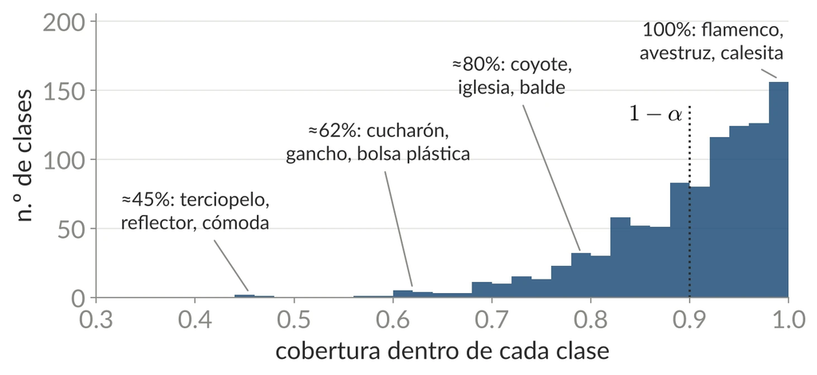

90% en promedio, pero 12% de las clases quedan por debajo de 80%.

## Cobertura condicional

1. Scores por clase

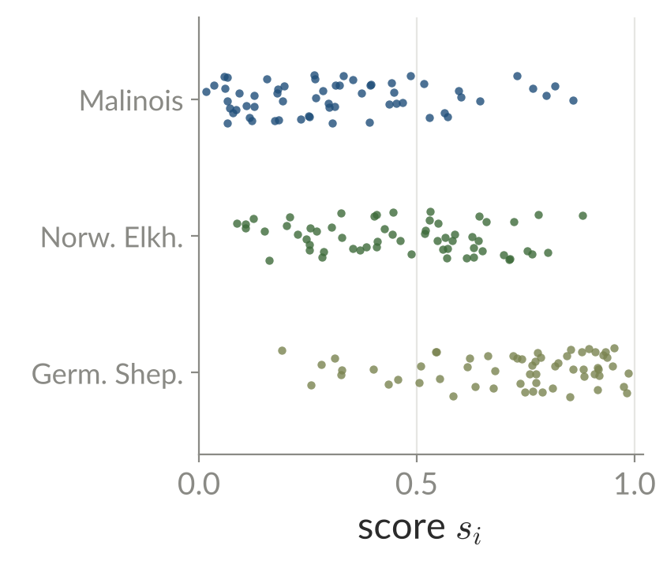

$\{s_i:\ Y_i=y\}$ para cada clase $y$

→

2. Un cuantil por clase

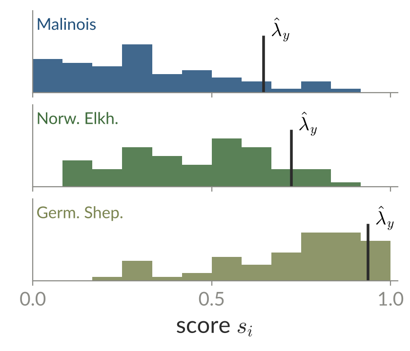

$\qh_y$ = cuantil de nivel $\tfrac{\lceil (n_y+1)(1-\alpha)\rceil}{n_y}$

→

3. Conjuntos en test

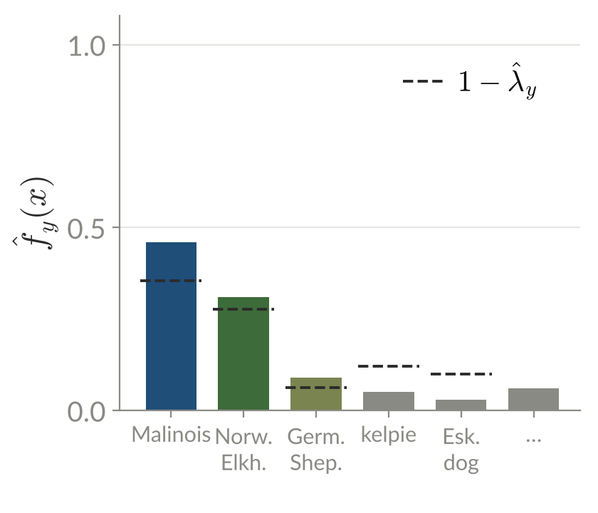

$\Ch(x)=\big\{y:\ \fh_y(x)\ge 1-\qh_y\big\}$

Teorema. [Vovk et al, 2005; Vovk, 2012] Si los datos son intercambiables, para cada clase $y$, $\ \P\big(Y_{n+1}\in\Ch(X_{n+1})\mid Y_{n+1}=y\big)\ge 1-\alpha$.

## Cobertura condicional

1. Scores por clase

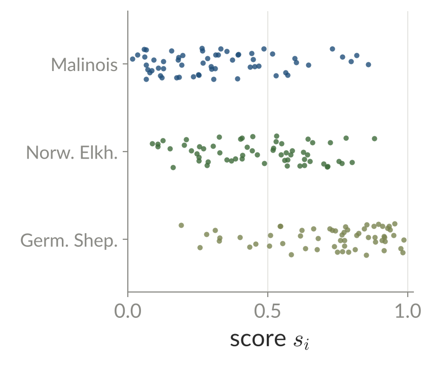

$\{s_i:\ Y_i=y\}$ para cada clase $y$

→

2. Un cuantil por clase

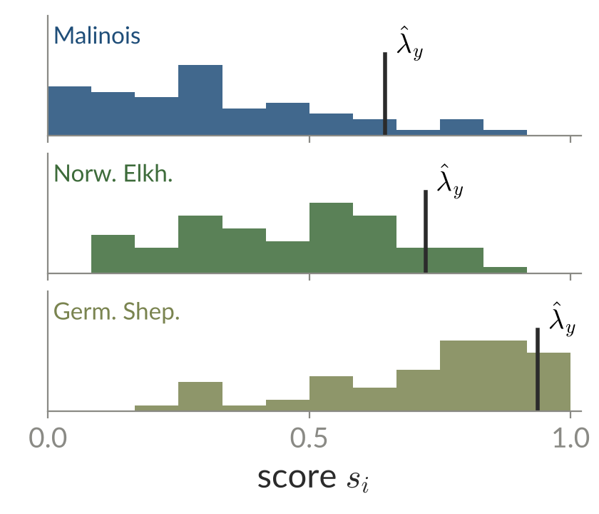

$\qh_y$ = cuantil de nivel $\tfrac{\lceil (n_y+1)(1-\alpha)\rceil}{n_y}$

→

3. Conjuntos en test

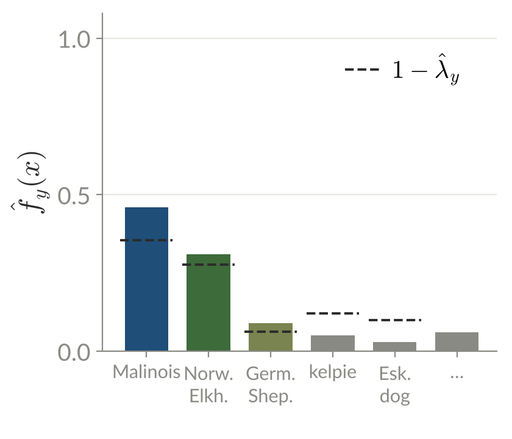

$\Ch(x)=\big\{y:\ \fh_y(x)\ge 1-\qh_y\big\}$

Más en general, con grupos $g(X,Y)\in\{1,\dots,G\}$ **disjuntos** y fijados de antemano, y un $\qh_g$ por grupo (datos intercambiables), entonces:

$$\P\big(Y_{n+1}\in\Ch(X_{n+1})\ \big|\ g(X_{n+1},Y_{n+1})=g\big)\ \ge\ 1-\alpha \quad\text{para cada } g$$

Ejemplos: la clase ($g=y$), grupos de edad, grupos demográficos, hospital, tipo de escáner.

[Vovk et al, 2005][Vovk, 2012]

## Cobertura condicional

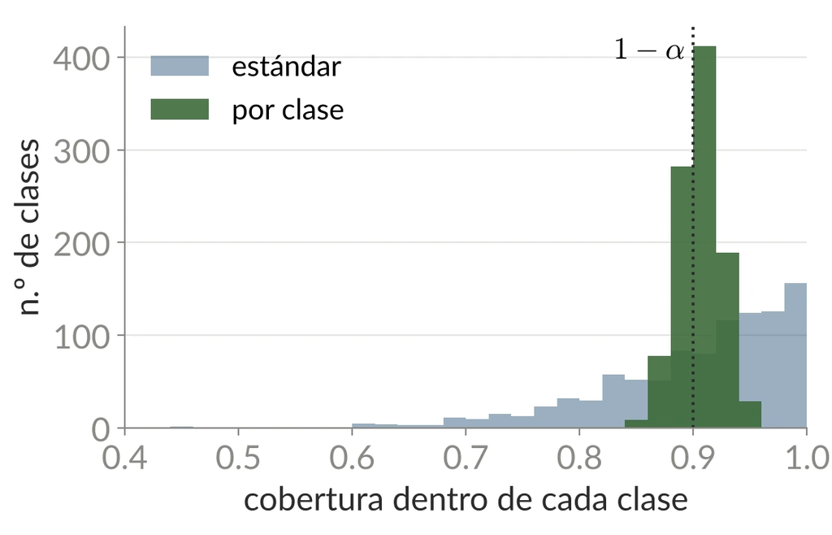

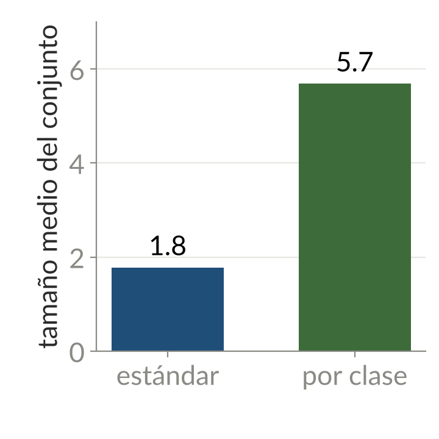

Precio: conjuntos más grandes.

[Ding, Angelopoulos, Bates, Jordan & Tibshirani, 2023]

Q2: ¿Cómo se generaliza y dónde se aplica?

CQR

clasificación

cobertura condicional

control de riesgo

en línea

## Regresión conformal en imágenes

Mediciones

Reconstrucción

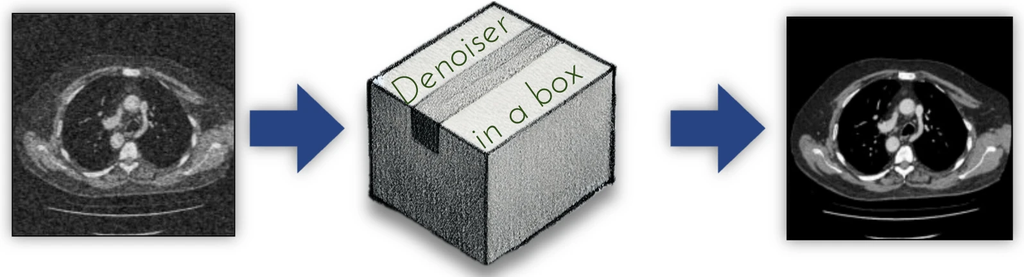

$X=AY+\epsilon,\ \ \epsilon\sim\mathcal N(0,\sigma^2\mathbb I)$

$\hat Y=f_\theta(X)\in\mathbb R^d$

¿Qué significa “cubrir” una imagen de $d$ píxeles?

$$\P\big(Y\notin C_{\qh}(X)\big)=\E\big[\mathbf 1\{Y\notin C_{\qh}(X)\}\big]\le\alpha$$

## De cobertura a riesgo

Split conformal controla el valor esperado de un indicador:

$$\P\big(Y\notin C_{\qh}(X)\big)=\E\big[\mathbf 1\{Y\notin C_{\qh}(X)\}\big]\le\alpha$$

Reemplazarlo por una **pérdida** $\ L\big(C_\lambda(X),Y\big)\in[0,B]$, **no creciente** en $\lambda$:

- fracción de píxeles fuera de la banda $\big[\hat l(X)-\lambda,\ \hat u(X)+\lambda\big]$
- fracción de etiquetas que faltan (multi-etiqueta, segmentación)
- la cobertura: $\ L=\mathbf 1\{Y\notin C_\lambda(X)\}$

## De cobertura a riesgo

$Y$ (verdadera)

$X$ (medición)

$\hat l(X)-\qh$

$\hat u(X)+\qh$

ancho

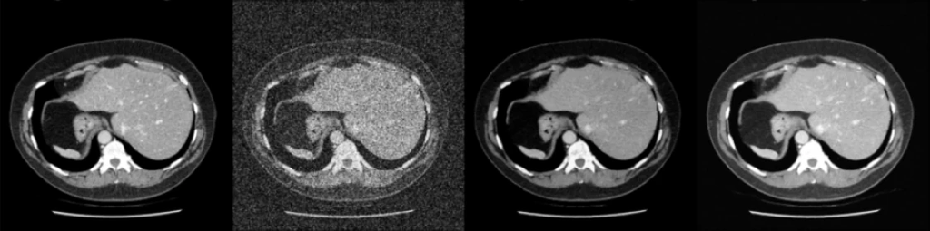

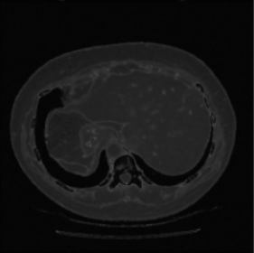

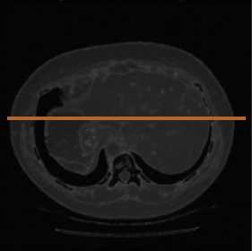

Un dato $=$ una imagen.

[Teneggi, Stayman & S., MICCAI 2025]

## De cobertura a riesgo

$L\big(C_\lambda(X),Y\big)$: fracción de **píxeles de $Y$** fuera de $\big[\hat l_j-\lambda,\ \hat u_j+\lambda\big]$

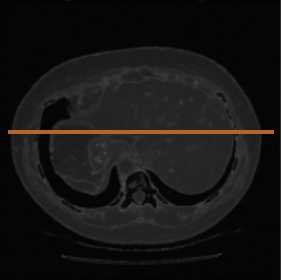

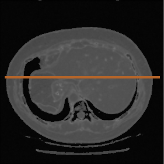

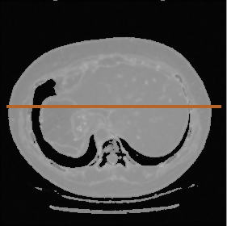

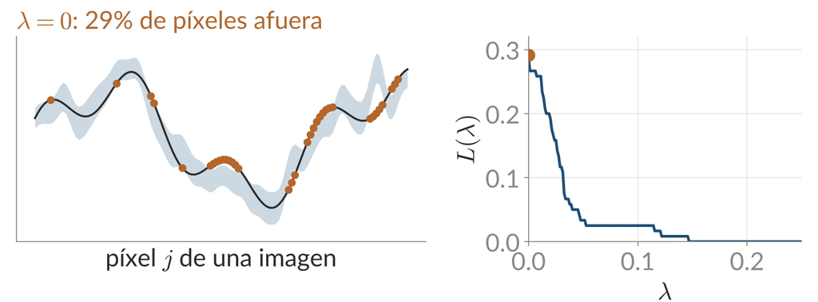

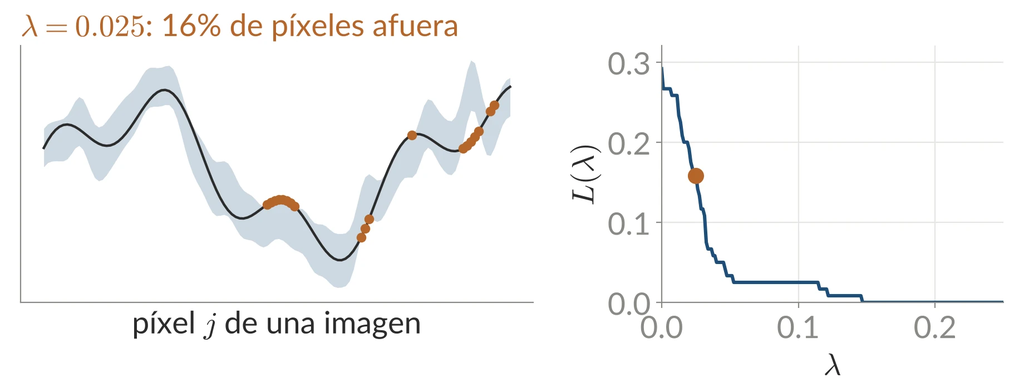

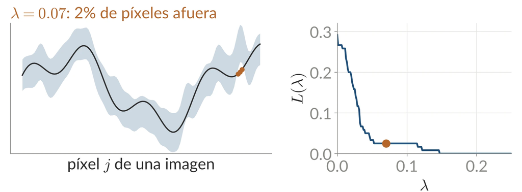

¿Cómo elegir $\lambda$ para que $\quad \E\big[L\big(C_{\qh}(X),Y\big)\big]\le\epsilon\$?

## De cobertura a riesgo

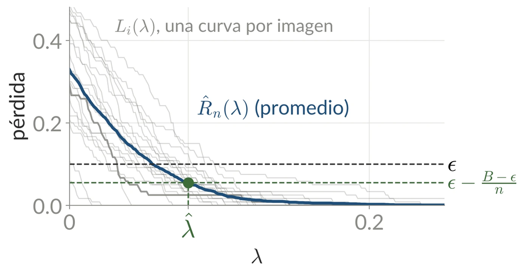

$$\hat\lambda = \inf\Big\{\lambda:\ \hat R_n(\lambda)\le \epsilon-\tfrac{B-\epsilon}{n}\Big\}, \qquad \hat R_n(\lambda)=\frac1n\sum_{i=1}^n L_i(\lambda)$$

Teorema. Si $L_1,\dots,L_{n+1}$ son intercambiables, $\quad \E\big[L_{n+1}(\hat\lambda)\big]\le\epsilon.$

**En alta probabilidad (RCPS):** con $L_i$ i.i.d. en $[0,1]$, reemplazar $\hat R_n$ por una cota superior de confianza, p. ej. $\ \hat R^+(\lambda)=\hat R_n(\lambda)+\sqrt{\log(1/\delta)/(2n)}$, y elegir $\ \hat\lambda=\inf\{\lambda:\ \hat R^+(\lambda')<\epsilon\ \ \forall\lambda'\ge\lambda\}$. Entonces

$$\P\big(R(\hat\lambda)\le\epsilon\big)\ge 1-\delta, \qquad R(\lambda)=\E\big[L_{n+1}(\lambda)\mid\text{calibración}\big]$$

Probabilidad sobre la calibración. Precio: corrección $\sim\sqrt{\log(1/\delta)/n}$ en vez de $B/n$. [Bates, Angelopoulos, Lei, Malik & Jordan, 2021]

[Angelopoulos, Bates, Fisch, Lei & Schuster, 2024]

## Regresión conformal en imágenes

**1. Alta dimensión.** Un único $\lambda$ para los $d\approx 10^5$ píxeles ensancha todos por igual: las regiones fáciles quedan con bandas innecesariamente anchas.

**2. Heterogeneidad.** Fondo, hueso, hígado, páncreas: el error del modelo depende del contenido, y la posición de cada órgano cambia de paciente a paciente.

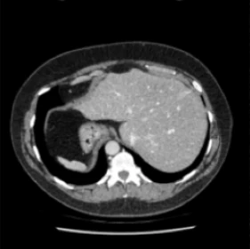

Un $\lambda$ **por tipo de contenido**: un $\lambda_k$ por órgano.

## Regresión conformal por órgano

Un modelo de segmentación $s(X)$ asigna cada píxel $j$ a un órgano $k$:

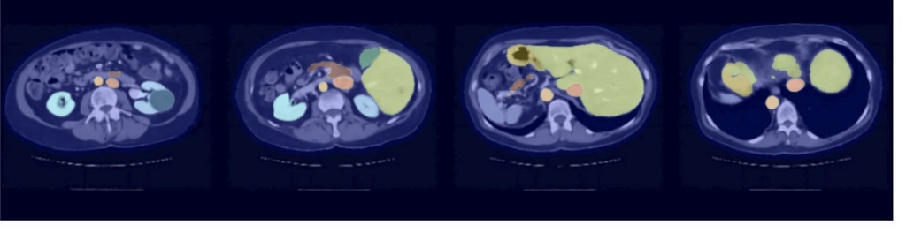

Un $\lambda_k$ por órgano: $\quad\big[\hat l_j(X)-\lambda_{s(X)_j},\ \hat u_j(X)+\lambda_{s(X)_j}\big]$

$L_k(\lambda)$ = fracción de píxeles **del órgano $k$** fuera de la banda. Calibrar cada $\hat\lambda_k$ como antes:
$$\E\big[L_k(\hat\lambda)\big]\le\epsilon \quad\text{para cada órgano } k$$

[Teneggi, Stayman & S., MICCAI 2025]

## Regresión conformal por órgano

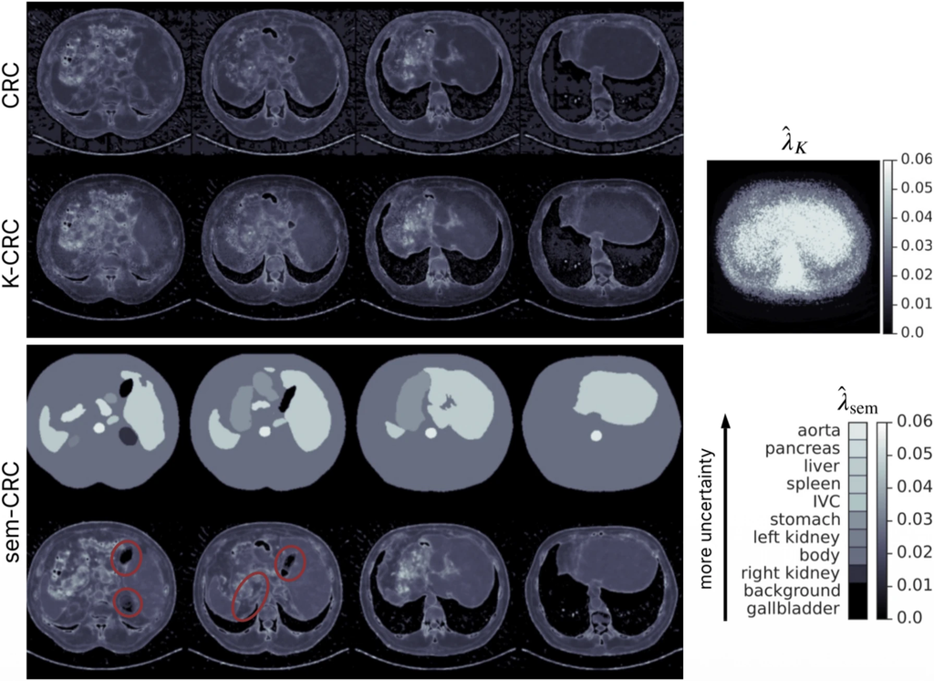

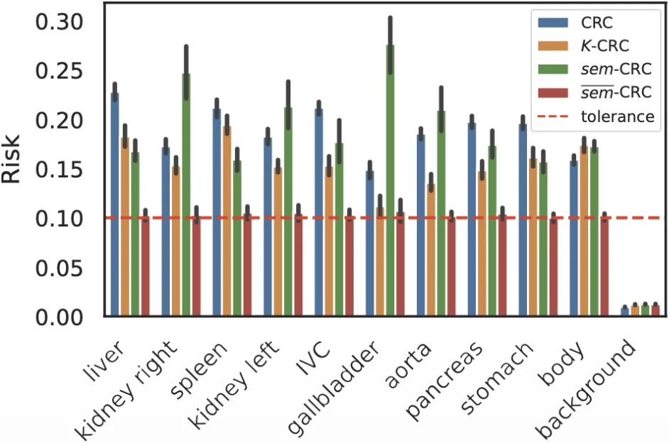

Ancho por píxel: más incertidumbre en aorta, páncreas, hígado.

Riesgo por órgano: solo un $\hat\lambda_k$ por órgano (rojo) da $\le\epsilon$ en cada uno.

[Teneggi, Stayman & S., MICCAI 2025]

Q2: ¿Cómo se generaliza y dónde se aplica?

CQR

clasificación

cobertura condicional

control de riesgo

en línea

## Conformal en línea

Alquileres de bicicletas por hora (Washington DC). En cada hora $t$:  
**1.** llegan $X_t$ (hora, día, clima) y publicamos $\ C_t=\big[\hat Y_t-\tau_t,\ \hat Y_t+\tau_t\big]$  
**2.** se observa $Y_t$: cubrimos si $\ S_t=|Y_t-\hat Y_t|\le\tau_t$ $\qquad$ **3.** actualizamos $\tau_{t+1}$

[figure not shown]

**Objetivo,** para **cualquier** secuencia: $\ \ \frac1T\sum_{t\le T}\mathbf 1\{S_t\le\tau_t\}\ \longrightarrow\ 1-\alpha$

Sin asumir nada de los datos (intercambiables, independientes, ninguna distribución).

## En línea y por grupos

Alquileres de bicicletas por hora (Washington DC). En cada hora $t$:  
**1.** llegan $X_t$ (hora, día, clima) y publicamos $\ C_t=\big[\hat Y_t-\tau_t,\ \hat Y_t+\tau_t\big]$  
**2.** se observa $Y_t$: cubrimos si $\ S_t=|Y_t-\hat Y_t|\le\tau_t$ $\qquad$ **3.** actualizamos $\tau_{t+1}$  
Grupos $\ c_j(X)\in[0,1]$: hora pico, noche, fin de semana, lluvia; $\ \ T_j=\sum_{t\le T}c_j(X_t)$

[figure not shown]

**Objetivo,** para **cada** grupo $j$: $\ \ \frac{1}{T_j}\sum_{t\le T}c_j(X_t)\,\mathbf 1\{S_t\le\tau_t\}\ \longrightarrow\ 1-\alpha$

Sin asumir nada de los datos (intercambiables, independientes, ninguna distribución).

## Conformal en línea y por grupos

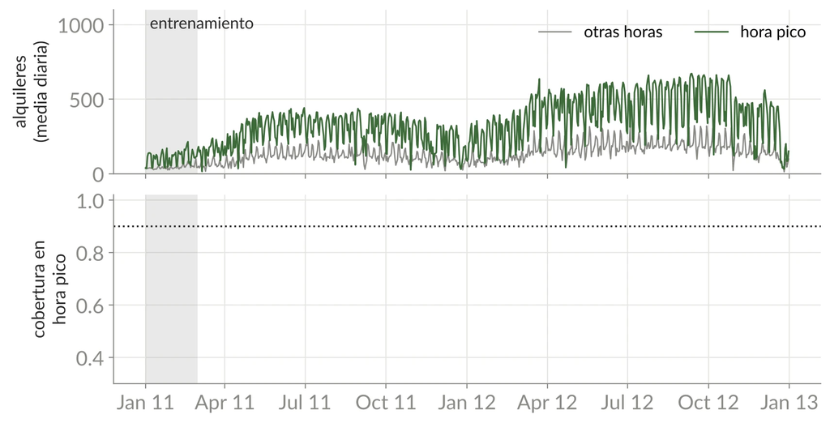

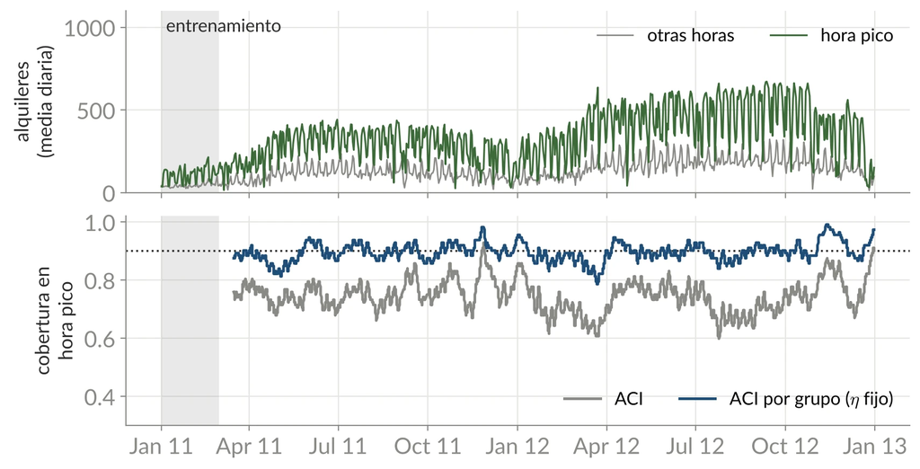

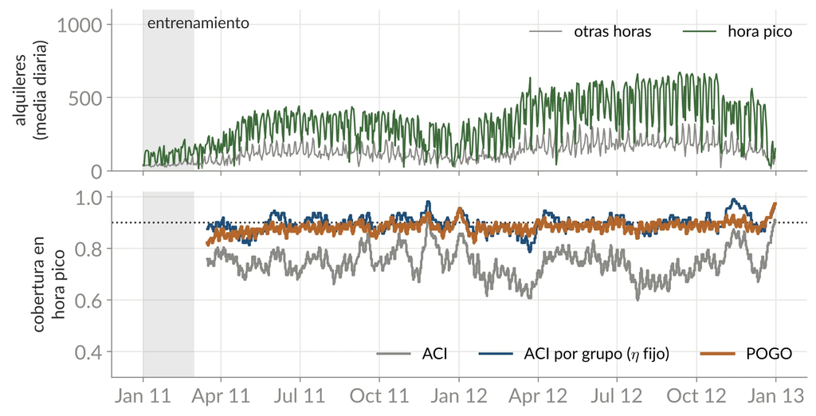

Entrenado en invierno y el uso se triplica: ~90% por grupo,  
POGO sin necesidad de elegir parámetros (“parameter-free”).

| método | cobertura por grupo | ancho medio |
| --- | --- | --- |
| ACI (un radio) | 75–100% | 583 |
| ACI por grupo, $\eta=1$ | 85–96% | 450 |
| ACI por grupo, $\eta=10$ | 90% | 458 |
| ACI por grupo, $\eta=100$ | 90% | 498 |
| **POGO** (sin $\eta$) | 88–92% | **445** |

Marzo 2011 – diciembre 2012; 5 grupos (todas, hora pico, noche, fin de semana, lluvia). Ancho en bicicletas.

[Gibbs & Candès, 2021][Bharti, Pal, Teneggi & S., 2026]

## Resumen

- Split conformal: **cualquier** predictor puntual -> intervalos con cobertura $\ge 1-\alpha$, usando $n$ datos de calibración.
- La garantía se deduce de **intercambiabilidad + rangos**; es marginal.
- El **score** depende del problema: CQR, APS, por grupo, por píxel, por órgano.
- Si los datos cambian en el tiempo: actualizar en línea (ACI, POGO).

## Referencias

Para empezar:

Angelopoulos & Bates, *A Gentle Introduction to Conformal Prediction and Distribution-Free UQ*, 2023

Angelopoulos, Barber & Bates, *Theoretical Foundations of Conformal Prediction*, 2024

Vovk, Gammerman & Shafer, *Algorithmic Learning in a Random World*, 2005

Gracias:  
Jacopo Teneggi · Beepul Bharti · Ambar Pal

Funding: NSF CAREER CCF-2239787 · NIH R01CA287422

jsulam.github.io · jsulam1@jhu.edu

[figure not shown]

[figure not shown]